**Nome**: *Federico*  
**Cognome**: *Signoretta*  
**Numero matricola**: 847343  
**E-mail**: f.signoretta@campus.unimib.it  
**A.A.** 2019-2020

# Digital Signal and Image Management

- Docente: *Simone Bianco*
- Docente: *Marco Buzzelli*
- Esercitatore: *Simone Zini*

## Assignment n.1

**Descrizione**: classificazione dei segnali audio monocanali attraverso SVC. Il dataset è composto da tracce audio in cui vengono pronunciati i numeri da 0 a 9, da tre differenti soggetti. I numeri rappresentano le 10 classi da predirre. Quindi, implementare la feature *Zero-Crossing Rate (ZCR)* per la descrizione di un segnale audio monocanale, in aggiunta a *deviazione standard, media, media assoluta, durata ed energia* del segnale. Verificare l'effetto dell'uso di ZCR in combinazione con altre feature presentate ad esercitazione.

### 1. Import dei pacchetti

```python
import os
import numpy as np
import pandas as pd
from time import time
from scipy.io import wavfile as wav

import matplotlib.pyplot as plt
import IPython.display as ipd

# Strumenti di classificazione
from sklearn.svm import SVC
from sklearn.model_selection import train_test_split, GridSearchCV
from sklearn.metrics import classification_report, confusion_matrix

# Feature audio avanzate
import librosa
import librosa.display as lid
from sklearn.preprocessing import scale

from scipy.io import wavfile as wav
```

### 2. Data loader

#### 2.1 Caricamento delle tracce .wav, estrazione della rispettiva label, divisione in training e test set e normalizzazione

```python
# Segnaposto per feature extractor
def identity(input):
    return input

# Data loader
def load_data(feature_extractor=identity, normalize=True):

    labels = []
    features = []

    for f in sorted(os.listdir('./recordings')):
        if f.endswith('.wav'):
            # Carica file ed estraine le features
            _, signal = wav.read('./recordings/' + f)
            cur_features = feature_extractor(signal)
            features.append(cur_features)

            # Categorie
            label = f.split('_')[0]
            labels.append(label)

    # X: features, y: labels
    X_train, X_test, y_train, y_test = train_test_split(features, labels, test_size=0.1, random_state=1)

    if normalize:
        eps = 0.001
        X_train = np.array(X_train)
        X_train_mean = X_train.mean(axis=0)
        X_train_std = X_train.std(axis=0)
        X_train = (X_train - X_train_mean + eps)/(X_train_std + eps)
        X_train = [row for row in X_train]

        X_test = [row for row in (np.array(X_test) - X_train_mean + eps)/(X_train_std + eps)]

    return X_train, X_test, y_train, y_test
```

#### 2.2. Esempio di traccia audio

```python
# Riprodurre segnale
audio_rate, audio = wav.read('./recordings/1_nicolas_28.wav')
ipd.Audio(audio, rate=audio_rate)
```

[interactive chart not shown]

### 3. Creazione delle features

```python
def crop(input, size=100):
    # Elimina eventuali valori oltre il numero consentito
    output = input[0:min(size, input.shape[0])]
    # Aggiungi valori nulli per raggiungere la dimensione richiesta
    output = np.concatenate((output, np.zeros(size-output.shape[0])))
    return output
```

#### 3.1 Creazione delle features *deviazione standard, media, media assoluta, durata ed energia*

```python
def sdev(input):
    return np.std(input, keepdims=True)

def avg(input):
    return np.mean(input, keepdims=True)

def aavg(input):
    return np.mean(np.abs(input), keepdims=True)

def duration(input):
    return input.shape

def energy(input):
    return np.sum((input*1.0)**2, keepdims=True)
```

#### 3.2 Creazione della feature Zero-Crossing Rate (ZCR)

Per short-time average ZCR s'intende il numero di volte in cui il segnale attraversa lo zero in un tempo unitario. La funzione da implemenetare è la seguente:

$$ ZCR = \frac{1}{2}\sum_{k=n}^{n+N+1}|sgn(s_w(k))-sgn(s_w(k-1))|$$

dove $sgn(\cdot)$ è la funzione segno, $w$ è la funzione finestra e $s_w(k)$ è il segnale dopo il *windowing processing*.

```python
def zcr(input):
    return np.sum(np.abs(np.diff(np.sign(input))), keepdims=True)*0.5
```

#### 3.3 Funzione per concatenare le features create

##### 3.3.1 Concatenazione delle features **senza ZCR**

```python
def combo(input):
    return np.concatenate((aavg(input),sdev(input),duration(input),energy(input)))
```

##### 3.3.2 Concatenazione delle features **con ZCR**

```python
def combo_zcr(input):
    return np.concatenate((aavg(input),sdev(input),duration(input),energy(input),zcr(input)))
```

### 4. Caricamento dati

#### 4.1 Caricamento e divisione in training e test set, senza ZCR

```python
# Caricamento dati
X_train, X_test, y_train, y_test = load_data(feature_extractor=combo)
```

```python
print("Il training set è composto da", len(X_train), "tracce audio,con cardinalità pari a", len(X_train[0][:100]))
print("Il test set è composto da", len(X_test), "tracce audio, con cardinalità pari a", len(X_test[0]))
```

```
Il training set è composto da 1350 tracce audio,con cardinalità pari a 4
Il test set è composto da 150 tracce audio, con cardinalità pari a 4
```

#### 4.2 Caricamento e divisione in training e test set, con ZCR

```python
# Caricamento dati con ZCR
X_train_zcr, X_test_zcr, y_train_zcr, y_test_zcr = load_data(feature_extractor=combo_zcr)
```

```python
print("Il training set è composto da", len(X_train_zcr), "tracce audio, con cardinalità pari a", len(X_train_zcr[0]))
print("Il test set è composto da", len(X_test_zcr), "tracce audio, con cardinalità pari a", len(X_test_zcr[0]))
```

```
Il training set è composto da 1350 tracce audio, con cardinalità pari a 5
Il test set è composto da 150 tracce audio, con cardinalità pari a 5
```

### 5. Addestramento modelli

Il modello utilizzato per la classificazione è **SVC**, i cui iper-parametri vengono ottimizzati attraverso il metodo **GridSearch** con 2-cross validation.

#### 5.1 Ricerca degli iper-parametri e addestramento del modello senza ZCR

```python
# Caricamento dati
X_train, X_test, y_train, y_test = load_data(feature_extractor=combo)
```

```python
# Parametri da provare in cross validation
param_grid = {'C': [1e3, 1.5e3, 2e3, 2.5e3, 3e3, 3.5e3],
              'gamma': [0.1, 0.25, 0.5, 0.75, 1.0],
              'kernel': ["sigmoid", "rbf"]}

# Inizializzazione Support Vector Machine
clf = GridSearchCV(SVC(class_weight='balanced'), param_grid, cv=2)
```

```python
# Addestramento
%time clf = clf.fit(X_train, y_train)
```

```
Wall time: 43.2 s
```

```python
# Risultato della cross validation per la selezione dei parametri
print("Migliore combinazione di parametri:")
print(" C: ", str(clf.best_estimator_.C))
print(" gamma: ", str(clf.best_estimator_.gamma))
print(" kernel: ", str(clf.best_estimator_.kernel))
```

```
Migliore combinazione di parametri:
 C:  3500.0
 gamma:  0.5
 kernel:  rbf
```

#### 5.2 Ricerca degli iper-parametri e addestramento del modello con ZCR

```python
# Inizializzazione Support Vector Machine
clf_zcr = GridSearchCV(SVC(class_weight='balanced'), param_grid, cv=2)
%time clf_zcr = clf_zcr.fit(X_train_zcr, y_train_zcr)
```

```
Wall time: 23.1 s
```

```python
# Risultato della cross validation per la selezione dei parametri
print("Migliore combinazione di parametri:")
print(" C: ", str(clf_zcr.best_estimator_.C))
print(" gamma: ", str(clf_zcr.best_estimator_.gamma))
print(" kernel: ", str(clf_zcr.best_estimator_.kernel))
```

```
Migliore combinazione di parametri:
 C:  2500.0
 gamma:  0.1
 kernel:  rbf
```

### 6. Performance dei modelli sul test set

#### 6.1 Performance sul test set del modello senza ZCR

```python
# Test
y_pred = clf.predict(X_test)

# Report di classificazione
print("Report di classificazione:")
report = classification_report(y_test, y_pred, output_dict=True)
print(classification_report(y_test, y_pred))
```

```
Report di classificazione:
              precision    recall  f1-score   support

           0       0.56      0.59      0.57        17
           1       0.27      0.40      0.32        10
           2       0.29      0.33      0.31        15
           3       0.47      0.37      0.41        19
           4       0.35      0.55      0.43        11
           5       0.30      0.21      0.25        14
           6       0.69      0.79      0.73        14
           7       0.56      0.26      0.36        19
           8       0.44      0.41      0.42        17
           9       0.35      0.43      0.39        14

    accuracy                           0.43       150
   macro avg       0.43      0.43      0.42       150
weighted avg       0.44      0.43      0.42       150
```

```python
# Accedo ai dati del classification_report e salvo i dati in un dataframe
report = pd.DataFrame.from_dict(report).transpose()
f1_score = report['f1-score']
```

```python
# funzione per la creazione della matrice di confusione
def confusion_map(real, pred):

    cm = confusion_matrix(real, pred)
    fig, ax = plt.subplots(figsize=(7, 5))
    im = ax.imshow(cm, cmap=plt.cm.Blues)

    ax.set_xticks(np.arange(10))
    ax.set_yticks(np.arange(10))

    ax.set_xticklabels(np.arange(10))
    ax.set_yticklabels(np.arange(10))

    for i in range(10):
        for j in range(10):
            text = ax.text(j, i, cm[i, j],
                           ha="center", va="center")

    ax.set_title("Matrice di confusione")
    fig.tight_layout()
    plt.show()
```

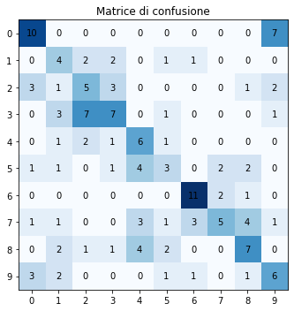

```python
confusion_map(y_test, y_pred)
```

#### 6.2 Performance sul test set del modello con ZCR

```python
# Test
y_pred_zcr = clf_zcr.predict(X_test_zcr)

# Report di classificazione
print("Report di classificazione:")
report_zcr = classification_report(y_test_zcr, y_pred_zcr, output_dict=True)
print(classification_report(y_test_zcr, y_pred_zcr))
```

```
Report di classificazione:
              precision    recall  f1-score   support

           0       0.81      0.76      0.79        17
           1       0.56      0.90      0.69        10
           2       0.60      0.60      0.60        15
           3       0.85      0.58      0.69        19
           4       0.44      0.73      0.55        11
           5       0.38      0.43      0.40        14
           6       0.93      0.93      0.93        14
           7       0.89      0.42      0.57        19
           8       0.56      0.59      0.57        17
           9       0.73      0.79      0.76        14

    accuracy                           0.65       150
   macro avg       0.67      0.67      0.65       150
weighted avg       0.70      0.65      0.65       150
```

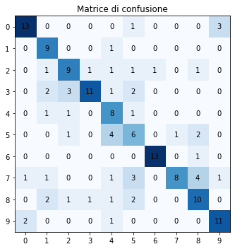

```python
confusion_map(y_test_zcr, y_pred_zcr)
```

```python
# Accedo ai dati del classification_report e salvo i dati in un dataframe
report_zcr = pd.DataFrame.from_dict(report_zcr).transpose()
f1_score_zcr = report_zcr['f1-score']
```

### 7. Conclusioni

#### 7.2 Creazione del plot con le differenza di performance tra i due modelli

```python
f1 = pd.concat([f1_score, f1_score_zcr], axis=1)
f1.columns = ['clf','clf_zcr']
f1=f1.reset_index()
macro = f1[f1['index']=='macro avg']
macro = macro.transpose()
new_header = macro.iloc[0]
macro = macro[1:]
macro.columns = new_header
```

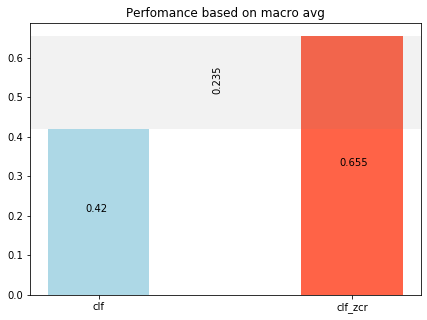

```python
fig, ax = plt.subplots(figsize=(7, 5))

ax.bar(macro.index,macro['macro avg'], width=0.4, color=['lightblue','tomato'])
for i, v in enumerate(macro['macro avg']):
    ax.text(i-.05, v/2 , str(round(v,3)), color='black')

diff = macro['macro avg'][1]-macro['macro avg'][0]
ax.axhspan(macro['macro avg'][0], macro['macro avg'][1], facecolor='gray', alpha=0.1)
ax.text(.45, 0.75-diff , str(round(diff,3)), color='black',rotation=90)
ax.set_title("Perfomance based on macro avg")

plt.show()
```

#### 7.2 Considerazioni finali

Come prima cosa è possibile osservare che la combinazione degli iper-parametri ottenuta dalla GridSearch è differente per i due modelli. Infatti, il modello **clf** (il modello iniziale senza la feature *zcr*) ottiene la migliore perfomance con $C=3,500$ e $\gamma=0.5$. Il modello **clf_zcr**, invece, ottiene la migliore perormance con $C=2,500$ e $\gamma=0.1$. La funzione kernel migliore per entrambi i modelli risulta essere la RBF.  
Infine, osservando le matrici di confusione e le relative perfomance sui dati di test è possibile osservare che il modello in cui è presente la feature *zcr*, ottiene risultati migliori: basandoci sulla misura *macro avg*, si ottiene un miglioramento di circa il 24%. Per cui è possibile affermare che la features *zcr*, che può riflettere la natura dello spettro del segnale in una certa misura, risulta avere un notevole impatto sulle performance del classificatore.